# Horticultural export competitiveness and risk with agriTradeRisk

```r
library(agriTradeRisk)
```

Export growth in horticulture can come with rising risk: dependence on a few destinations, sensitivity to exchange rates, weak transmission of world prices to growers and entry barriers in new markets. `agriTradeRisk` puts these dimensions in one reproducible workflow.

The example data describe Indian exports of mango, grapes, pomegranate and processed products to eight destinations. **They are simulated** for illustration and are not official trade statistics; replace them with data from sources such as UN Comtrade, DGCI&S or APEDA for empirical work.

```r
head(hort_exports)
```

```
#>   year product destination export_value export_quantity world_import
#> 1 2010   mango         UAE       31.370           18237       350.16
#> 2 2011   mango         UAE       26.049           17642       406.54
#> 3 2012   mango         UAE       27.945           16783       430.91
#> 4 2013   mango         UAE       38.016           20924       443.18
#> 5 2014   mango         UAE       39.427           26986       490.90
#> 6 2015   mango         UAE       46.387           29095       484.47
```

## 1. Destination concentration

```r
ec <- export_concentration(hort_exports, value = "export_value",
                           partner = "destination",
                           by = c("product", "year"))
subset(ec, year %in% c(2010, 2023),
       c(product, year, hhi, equivalent_partners, top_share,
         leading_partner, leading_share))
```

```
#>        product year       hhi equivalent_partners top_share leading_partner
#> 1       grapes 2010 0.3064015            3.263691 0.8027010     Netherlands
#> 14      grapes 2023 0.2699796            3.703983 0.8043329              UK
#> 15       mango 2010 0.3543028            2.822444 0.8098177             UAE
#> 28       mango 2023 0.4645840            2.152463 0.8588060             UAE
#> 29 pomegranate 2010 0.1955417            5.113997 0.6846011             UAE
#> 42 pomegranate 2023 0.1819519            5.495958 0.6471147             UAE
#> 43   processed 2010 0.1790101            5.586276 0.6568046             USA
#> 56   processed 2023 0.1843062            5.425754 0.6735960             USA
#>    leading_share
#> 1      0.4823765
#> 14     0.3615895
#> 15     0.5579369
#> 28     0.6635575
#> 29     0.3090770
#> 42     0.2959197
#> 43     0.2472052
#> 56     0.2470270
```

An HHI above 0.25 (fewer than four equivalent markets) signals heavy dependence on a small number of destinations.

## 2. Competitiveness

```r
py <- aggregate(cbind(export_value, world_import) ~ product + year,
                data = hort_exports, FUN = sum)
ci <- competitiveness_index(merge(py, trade_totals, by = "year"),
                            "export_value", "india_total_exports",
                            "world_import", "world_total_exports")
xtabs(round(rca, 2) ~ year + product, data = subset(ci, year >= 2019))
```

```
#>       product
#> year   grapes mango pomegranate processed
#>   2019   1.11  5.44        9.45      0.96
#>   2020   1.16  5.02        9.32      0.96
#>   2021   1.13  4.75       10.70      1.14
#>   2022   1.15  5.52       10.35      1.09
#>   2023   0.89  5.32        9.87      1.11
```

### Sources of export growth

```r
d0 <- subset(hort_exports, year == 2015)
d1 <- subset(hort_exports, year == 2023)
m <- merge(d0, d1, by = c("product", "destination"), suffixes = c("0", "1"))
cms <- cms_decomposition(m, "product", "destination", "export_value0",
                         "export_value1", "world_import0", "world_import1")
cms
```

```
#> Constant market share decomposition of export change
#>
#>                 effect  value share_of_change
#>           world_growth 374.92           65.6%
#>  commodity_composition  -4.04           -0.7%
#>    market_distribution -20.98           -3.7%
#>        competitiveness 221.20           38.7%
#>           total_change 571.10          100.0%
#>
#> Growth of world imports in the data: 51.0%
```

```r
cms$by_product
```

```
#>       product world_growth commodity_composition market_distribution
#> 1      grapes    104.10130              7.958924         -10.7802694
#> 2       mango     42.91001             12.394097           4.9975841
#> 3 pomegranate     59.86718            -17.000112           0.0383154
#> 4   processed    168.04545             -7.393349         -15.2365816
#>   competitiveness total_change
#> 1       -51.25796       50.022
#> 2        71.23231      131.534
#> 3        58.71562      101.621
#> 4       142.50548      287.921
```

A positive competitiveness effect means India gained market share beyond what world demand growth, product mix and market mix explain.

## 3. Price transmission

```r
pt <- price_transmission(grape_prices$domestic_price,
                         grape_prices$export_unit_value)
pt
```

```
#> Price transmission analysis (144 observations, log prices)
#>
#> Long-run elasticity:   0.834 (R2 = 0.848)
#> Engle-Granger ADF:     -4.614 (lag 0; 5% critical value -3.336) -> cointegrated at 5%
#> Short-run elasticity:  0.497
#> Adjustment speed:      -0.248 (p = 0.000)
#> Half-life (periods):   2.44
```

```r
pa <- price_transmission(grape_prices$domestic_price,
                         grape_prices$export_unit_value, asymmetric = TRUE)
pa
```

```
#> Price transmission analysis (144 observations, log prices)
#>
#> Long-run elasticity:   0.834 (R2 = 0.848)
#> Engle-Granger ADF:     -4.614 (lag 0; 5% critical value -3.336) -> cointegrated at 5%
#> Short-run elasticity:  0.496
#> Adjustment speed:      positive -0.299, negative -0.207
#> Half-life (periods):   positive 1.95, negative 2.98
#> Symmetry test:         F = 0.28, p = 0.595
```

## 4. Exchange-rate exposure

Shares of export earnings by invoicing currency:

```r
sh <- c(USD = 0.35, EUR = 0.20, GBP = 0.15, AED = 0.15, SAR = 0.05,
        BDT = 0.05, RUB = 0.05)
fx <- exchange_rate_exposure(fx_rates[, names(sh)], sh,
                             export_value = 5000, freq = 12)
fx
```

```
#> Exchange-rate exposure of export earnings
#>
#>  currency share volatility_annual risk_contribution
#>       USD 0.350             0.040             32.3%
#>       EUR 0.200             0.067             23.0%
#>       GBP 0.150             0.071             14.9%
#>       AED 0.150             0.040             13.8%
#>       SAR 0.050             0.040              4.6%
#>       BDT 0.050             0.046              4.6%
#>       RUB 0.050             0.198              6.8%
#>
#> Portfolio volatility (annual): 0.038
#> Undiversified volatility:      0.058
#> Diversification ratio:         1.528
#> Value at risk (95%, 1 period): parametric 91, historical 86
```

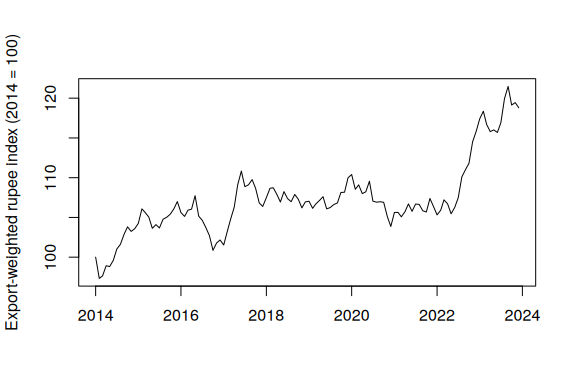

```r
plot(fx_rates$date, fx$effective_index, type = "l",
     xlab = "", ylab = "Export-weighted rupee index (2014 = 100)")
```

The diversification ratio shows how much currency risk is reduced by earning in several currencies; risk contributions show which currencies dominate the remaining exposure.

## 5. Market-entry risk

```r
mk <- data.frame(
  market = c("UAE", "Saudi Arabia", "UK", "Netherlands", "USA",
             "Bangladesh", "Nepal", "Russia"),
  sps_rejections = c(2, 3, 5, 8, 6, 1, 1, 4),
  tariff = c(0, 0, 0, 0, 2, 10, 5, 7),
  transit_days = c(4, 6, 18, 20, 30, 3, 2, 25),
  fx_volatility = c(0.04, 0.04, 0.07, 0.07, 0.04, 0.05, 0.01, 0.19),
  demand_growth = c(0.06, 0.05, 0.03, 0.04, 0.05, 0.08, 0.07, 0.02))
er <- market_entry_risk(mk, "market",
                        c("sps_rejections", "tariff", "transit_days",
                          "fx_volatility"),
                        higher_is_riskier = rep(TRUE, 4),
                        attractiveness = "demand_growth")
er[order(er$priority_rank),
   c("market", "risk_score", "risk_adjusted_attractiveness",
     "priority_rank")]
```

```
#>         market risk_score risk_adjusted_attractiveness priority_rank
#> 6   Bangladesh  0.3144841                    0.8427579             1
#> 7        Nepal  0.1250000                    0.7812500             2
#> 1          UAE  0.0952381                    0.6349206             3
#> 2 Saudi Arabia  0.1488095                    0.4627976             4
#> 5          USA  0.5202381                    0.3699405             5
#> 4  Netherlands  0.4940476                    0.2509921             6
#> 3           UK  0.3690476                    0.1359127             7
#> 8       Russia  0.7375000                    0.0000000             8
```

The indicator values here are hypothetical.

## 6. Risk-efficient destination mix

Using annual growth of grape export earnings by destination:

```r
g <- subset(hort_exports, product == "grapes")
wide <- reshape(g[, c("year", "destination", "export_value")],
                idvar = "year", timevar = "destination", direction = "wide")
vals <- as.matrix(wide[order(wide$year), -1])
colnames(vals) <- sub("export_value.", "", colnames(vals))
growth <- diff(log(vals))
current <- vals[nrow(vals), ] / sum(vals[nrow(vals), ])
md <- market_diversification(growth, shares = current, max_share = 0.35)
md
```

```
#> Mean-variance destination market analysis
#>
#> Shares
#>        market current minimum_variance best_return_to_risk
#>           UAE   0.097            0.240               0.247
#>  Saudi Arabia   0.048            0.129               0.150
#>            UK   0.362            0.170               0.196
#>   Netherlands   0.346            0.076               0.064
#>           USA   0.013            0.051               0.020
#>    Bangladesh   0.043            0.066               0.045
#>         Nepal   0.017            0.072               0.091
#>        Russia   0.075            0.196               0.187
#>
#> Portfolio statistics (per period)
#>                     return   risk  ratio    hhi
#> current             0.0480 0.0562 0.8541 0.2700
#> minimum_variance    0.0505 0.0224 2.2509 0.1594
#> best_return_to_risk 0.0522 0.0229 2.2857 0.1717
```

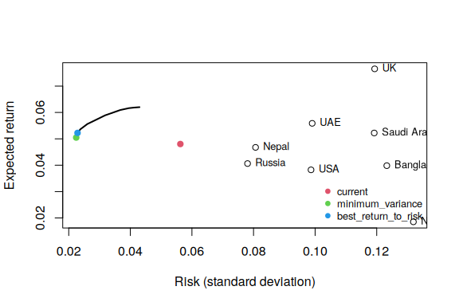

```r
plot(md)
```

Comparing the current mix with the efficient frontier shows how far re-orienting exports could reduce earnings risk without lowering expected growth. Upper bounds on shares represent market-size, access or logistics limits.